# HW3

### 1 and 2.

```r
suppressPackageStartupMessages(library(miceadds))
suppressPackageStartupMessages(library(tidyverse))
suppressPackageStartupMessages(library(skimr))
suppressPackageStartupMessages(library(factoextra))
suppressPackageStartupMessages(library(seriation))
suppressPackageStartupMessages(library(cluster))
suppressPackageStartupMessages(library(clValid))
Pdata <-load.Rdata2("legprof-components.v1.0.RData",path=getwd())
#munge the data
Pdata_sub <- Pdata[Pdata$sessid == "2009/10",]%>%dplyr::select(stateabv, t_slength, slength,salary_real, expend)%>%drop_na()
head(Pdata_sub)
```

|  | stateabv | t_slength | slength | salary_real | expend |
| --- | --- | --- | --- | --- | --- |
| 19 | AL | 116.55 | 104.55 | 1.050421 | 535.1423 |
| 38 | AK | 128.51 | 127.80 | 74.805863 | 1493.8351 |
| 57 | AZ | 286.13 | 197.38 | 48.393666 | 631.1329 |
| 76 | AR | 80.23 | 80.23 | 30.669025 | 516.6376 |
| 95 | CA | 390.00 | 270.00 | 213.405133 | 5523.1008 |
| 114 | CO | 205.20 | 205.20 | 60.492082 | 440.4498 |

```r
states = as.data.frame(Pdata_sub$stateabv)
data = Pdata_sub%>%dplyr::select(t_slength, slength,salary_real, expend)
data_scaled = scale(data)
data_dist_euc <- dist(data_scaled,
               method = "euclidean")
```

### 3.

Numerical analysis suggests the existence of a extreme outliers in distributions along all dimensions.

```r
###Figure out where the outliers are
suppressPackageStartupMessages(library(ggplot2))
skim(Pdata_sub)
```

|  | variable | type | stat | level | value | formatted |
| --- | --- | --- | --- | --- | --- | --- |
| 1 | stateabv | AsIs | missing | .all | 0.00000 | 0 |
| 2 | stateabv | AsIs | complete | .all | 49.00000 | 49 |
| 3 | stateabv | AsIs | n | .all | 49.00000 | 49 |
| 4 | stateabv | AsIs | n_unique | .all | 49.00000 | 49 |
| 5 | stateabv | AsIs | min_length | .all | 1.00000 | 1 |
| 6 | stateabv | AsIs | max_length | .all | 1.00000 | 1 |
| 7 | t_slength | numeric | missing | .all | 0.00000 | 0 |
| 8 | t_slength | numeric | complete | .all | 49.00000 | 49 |
| 9 | t_slength | numeric | n | .all | 49.00000 | 49 |
| 10 | t_slength | numeric | mean | .all | 147.79796 | 147.8 |

[output cut: 40 more lines]

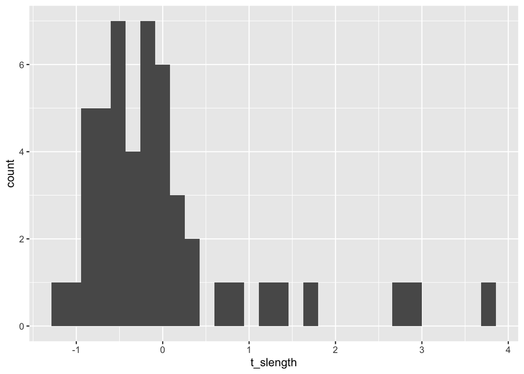

```r
ggplot(as.data.frame(data_scaled), aes(x=t_slength)) + geom_histogram()
```

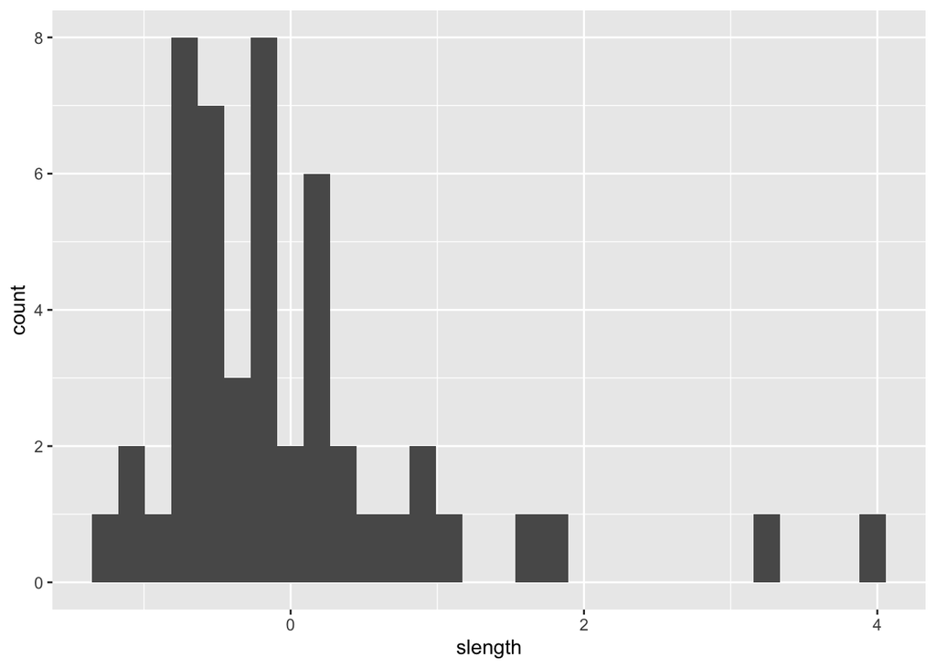

```r
ggplot(as.data.frame(data_scaled), aes(x=slength)) + geom_histogram()
```

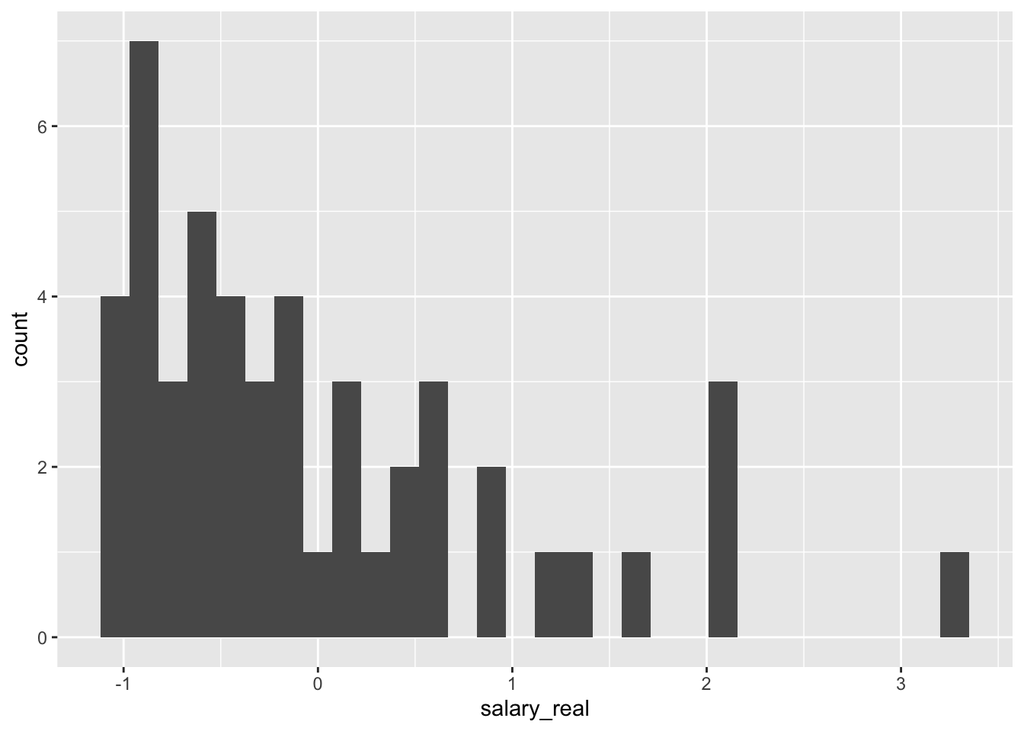

```r
ggplot(as.data.frame(data_scaled), aes(x=salary_real)) + geom_histogram()
```

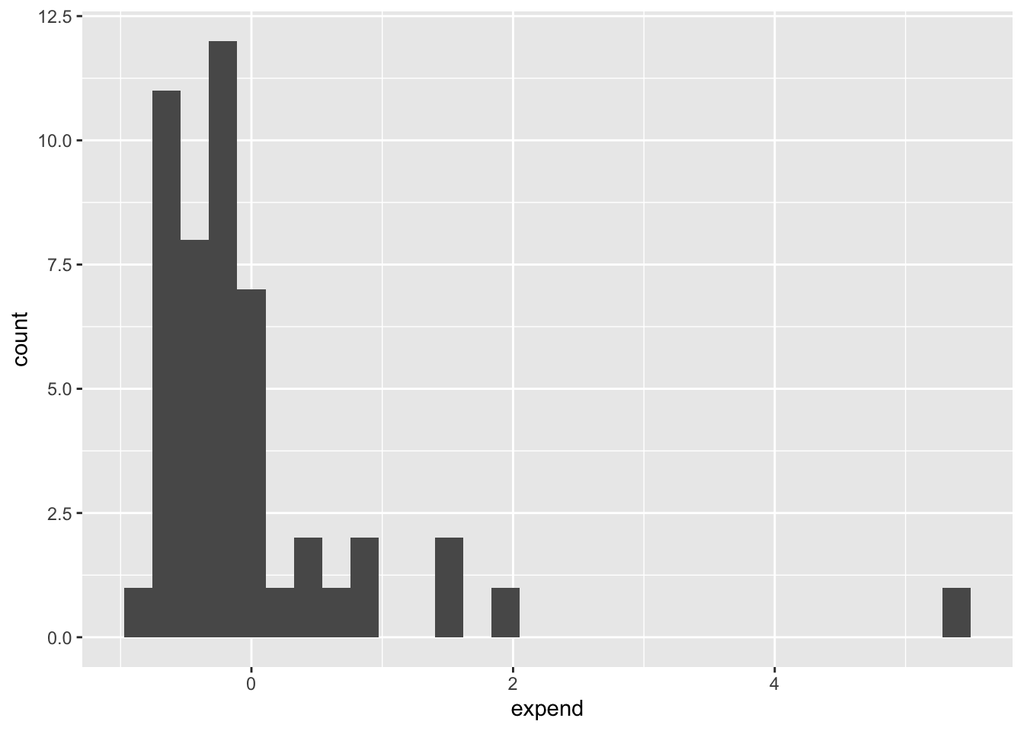

```r
ggplot(as.data.frame(data_scaled), aes(x=expend)) + geom_histogram()
```

```r
df <- as.data.frame(data_scaled)%>%dplyr::select(t_slength, slength,salary_real, expend)
```

A scatter plot is created at the end comparing one variable versus the other three. Once again, there are a few extreme outliers:

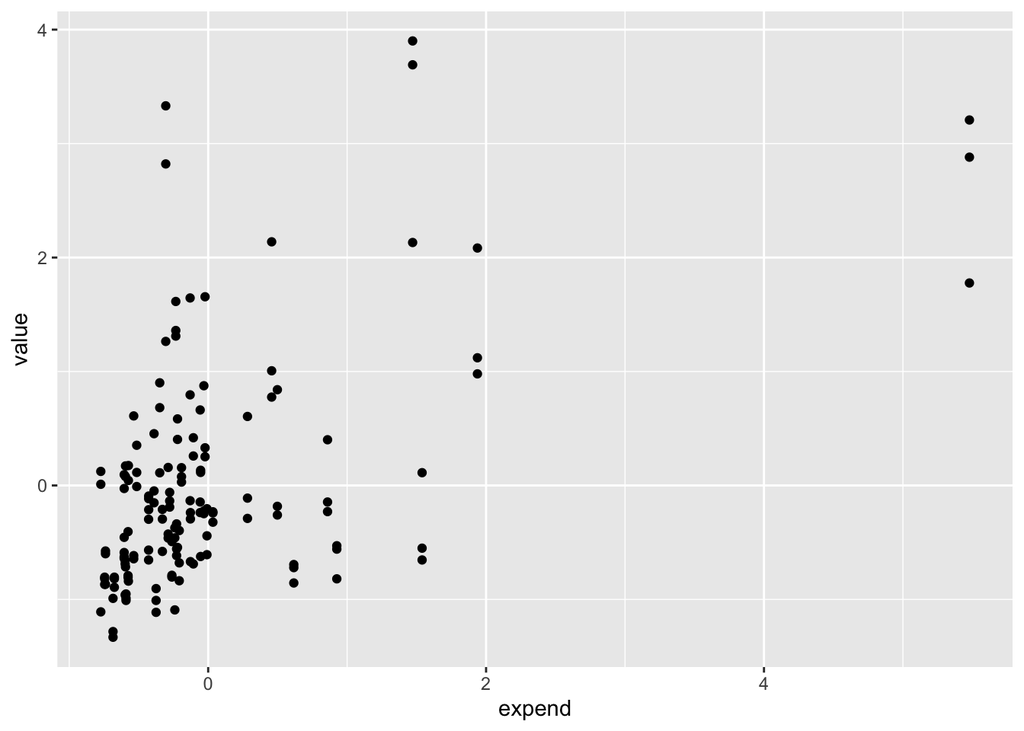

```r
df_melt=reshape2::melt(df, id.var = 'expend')
ggplot(df_melt,aes(x=expend,y=value)) + geom_point()
```

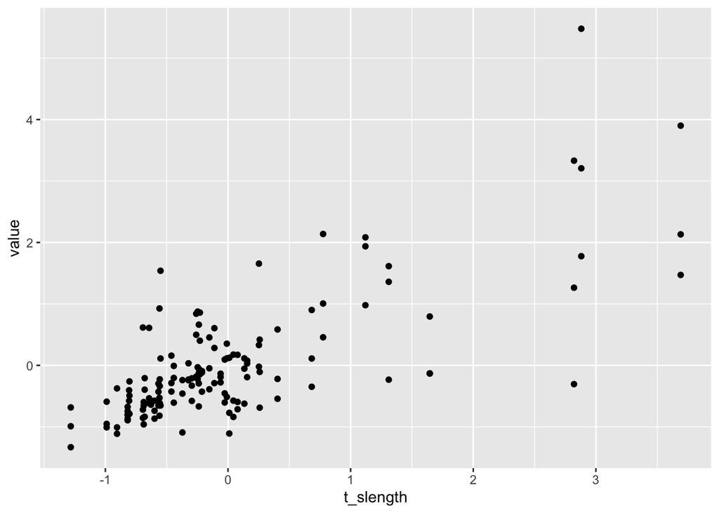

```r
df_melt=reshape2::melt(df, id.var = 't_slength')
ggplot(df_melt,aes(x=t_slength,y=value)) + geom_point()
```

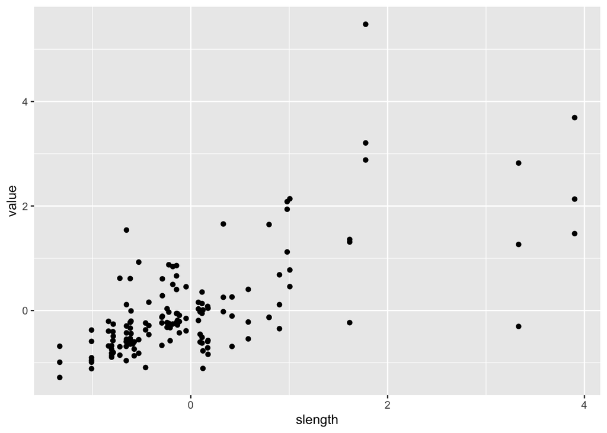

```r
df_melt=reshape2::melt(df, id.var = 'slength')
ggplot(df_melt,aes(x=slength,y=value)) + geom_point()
```

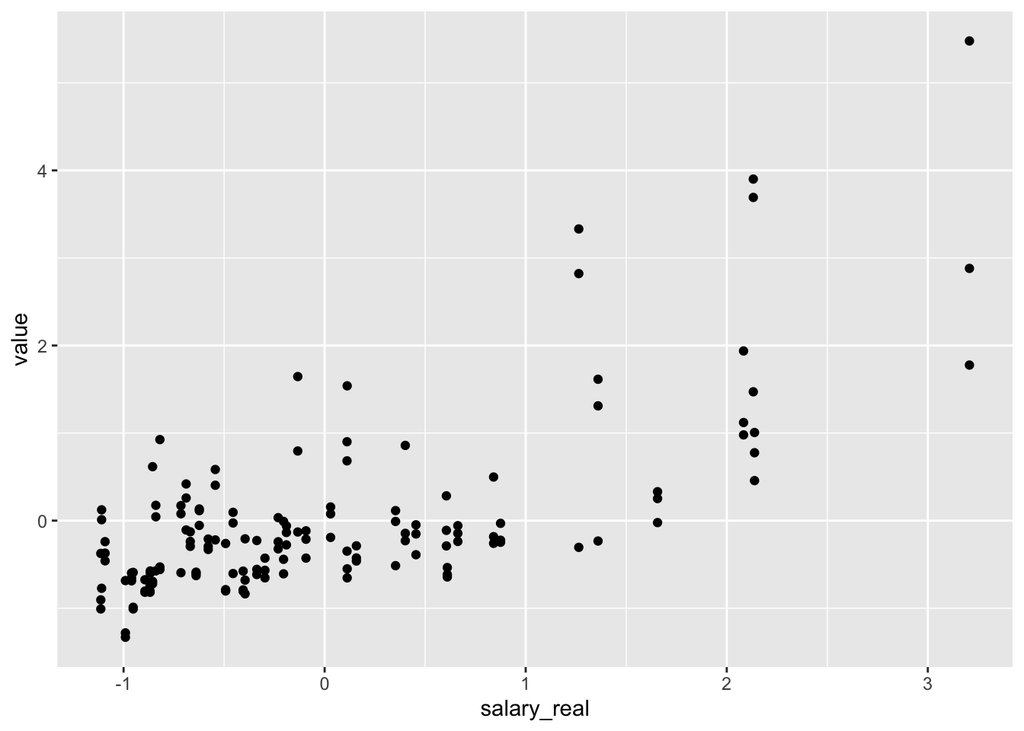

```r
df_melt=reshape2::melt(df, id.var = 'salary_real')
ggplot(df_melt,aes(x=salary_real,y=value)) + geom_point()
```

### 4.

We will calculate Hopkins statistic as well as the ODI plots for the different distance measures

```r
data_dist_euc <- dist(data_scaled,
               method = "euclidean")
data_dist_man <- dist(data_scaled,
               method = "manhattan")
data_dist_can <- dist(data_scaled,
               method = "canberra")
get_clust_tendency(data_scaled, nrow(data_scaled)-1, graph = FALSE, seed = 123)
```

```
## $hopkins_stat
## [1] 0.1723366
##
## $plot
## NULL
```

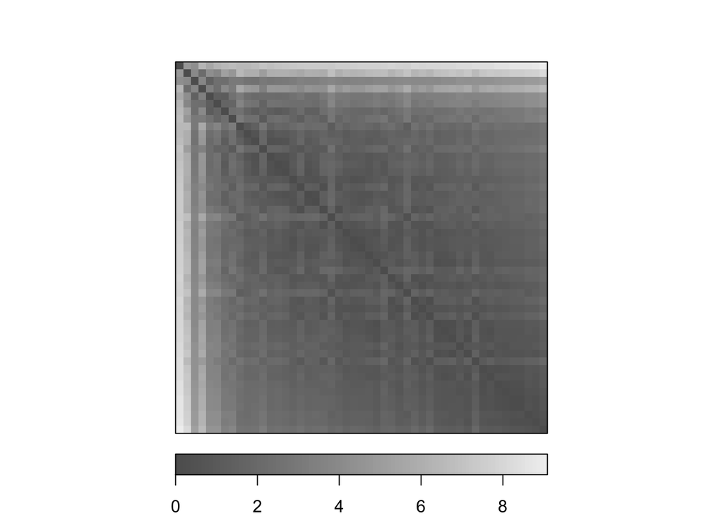

```r
dissplot(data_dist_euc)
```

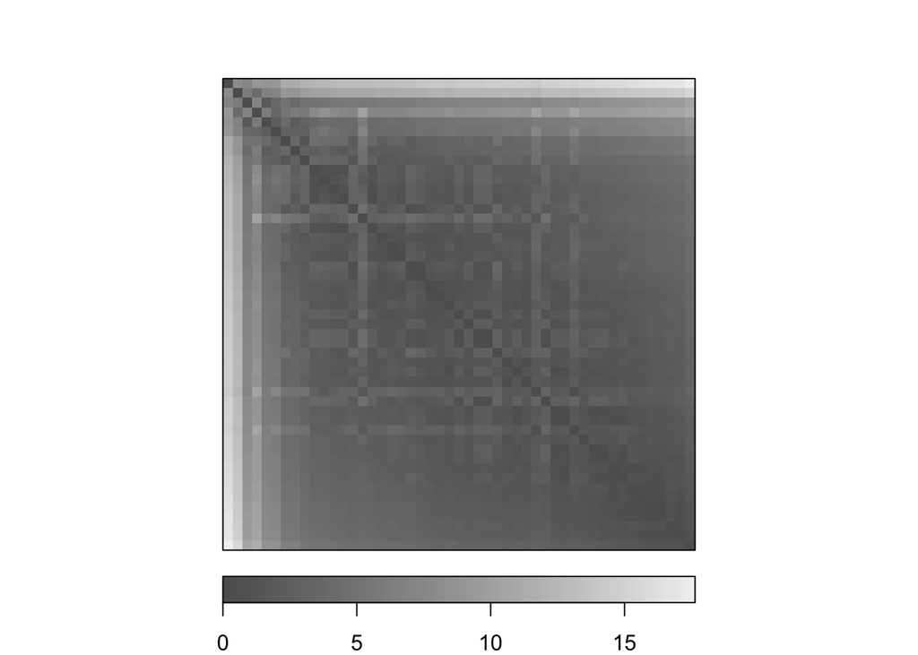

```r
dissplot(data_dist_man)
```

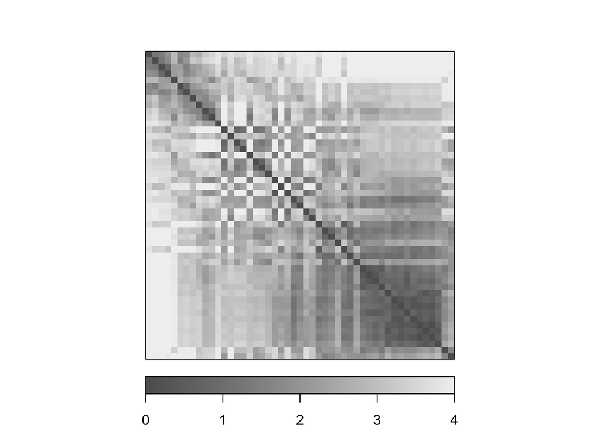

```r
dissplot(data_dist_can)
```

The Hopkins statistic suggests clusterability, however the picture with the ODI plots are not clear. Part of the problem might be the low number of data points leading to a low resolution picture, nevertheless the plot is hard to interpret. While the ODI plots for Manhattan and euclidean distance are similar, the ODI plot for the Canberra distance is very different, suggesting different clustering results.

### 5.

```r
set.seed(7355)
kmeans <- kmeans(data_scaled,
                 centers = 2,
                 nstart = 15)

#str(kmeans)
print ("Cluster assignments:")
```

```
## [1] "Cluster assignments:"
```

```r
kmeans$cluster
```

```
##  19  38  57  76  95 114 133 152 171 190 209 228 247 266 285 304 323 342
##   2   2   2   2   1   2   2   2   2   2   2   2   2   2   2   2   2   2
## 361 380 399 418 437 456 475 494 513 532 551 570 589 608 627 646 665 684
##   2   2   1   1   2   2   2   2   2   2   2   2   2   1   2   2   1   2
## 703 722 741 760 779 798 817 836 855 874 893 912 950
##   2   1   2   2   2   2   2   2   2   2   2   2   2
```

```r
print ("Cluster centers:")
```

```
## [1] "Cluster centers:"
```

```r
kmeans$centers
```

```
##    t_slength    slength salary_real     expend
## 1  2.1000302  2.1014710   2.0307585  1.4677087
## 2 -0.2930275 -0.2932285  -0.2833616 -0.2047966
```

```r
print ("Cluster sizes:")
```

```
## [1] "Cluster sizes:"
```

```r
kmeans$size
```

```
## [1]  6 43
```

```r
states$kcluster <- as.factor(kmeans$cluster)
print ("Total sum of squares")
```

```
## [1] "Total sum of squares"
```

```r
kmeans$totss/49
```

```
## [1] 3.918367
```

```r
print ("Average within cluster sum of squares in Cluster 1")
```

```
## [1] "Average within cluster sum of squares in Cluster 1"
```

```r
kmeans$withinss[1]/kmeans$size[1]
```

```
## [1] 6.726955
```

```r
print ("Average within cluster sum of squares in Cluster 2")
```

```
## [1] "Average within cluster sum of squares in Cluster 2"
```

```r
kmeans$withinss[2]/kmeans$size[2]
```

```
## [1] 1.124789
```

```r
print ("Total sum of squares:")
```

```
## [1] "Total sum of squares:"
```

```r
kmeans$totss
```

```
## [1] 192
```

```r
print ("Between sum of squares")
```

```
## [1] "Between sum of squares"
```

```r
kmeans$betweenss
```

```
## [1] 103.2723
```

```r
print ("Within sum sum of squares")
```

```
## [1] "Within sum sum of squares"
```

```r
kmeans$withinss
```

```
## [1] 40.36173 48.36594
```

We notice from the above that there are two clusters, one very big cluster and one smaller. This suggests that the smaller cluster might be outliers. The similar means of the individual variables suggest this to be the case. Given the comparison of the three average cluster sums, it seems like the smaller cluster is not compact and the bigger cluster is. This suggests the first cluster contains disparate outliers and the between sum of squares suggest a good separation between the clusters

### 6.

```r
suppressPackageStartupMessages(library(mixtools)) # fitting GMMs via EM (mixture modle)
library(plotGMM) # customizing GMM plot for visual output
set.seed(7355) # set seed for interations to return to same place

gmm1 <- mvnormalmixEM(data_scaled,
                    k = 2)
```

```
## number of iterations= 18
```

```r
#Calculating components
c1 <- which(data.frame(gmm1$posterior)$comp.1>0.5)

c2 <- which(data.frame(gmm1$posterior)$comp.2>0.5)

#Storing components in table
states$gmm=as.factor(ifelse(as.data.frame(gmm1$posterior)$comp.1>0.5,1,2))

print ("No of points in component 1:")
```

[output not shown]

```r
l1<-length(c2)
l1
```

```
## [1] 43
```

```r
print ("No of points in component 2:")
```

```
## [1] "No of points in component 2:"
```

```r
l2<-nrow(data_scaled)-l1
l2
```

```
## [1] 6
```

```r
print ("Constituents of component 1 from k-means:")
```

```
## [1] "Constituents of component 1 from k-means:"
```

```r
which(states$kcluster==1)
```

```
## [1]  5 21 22 32 35 38
```

```r
print ("Constituents of component 1 from gmm:")
```

```
## [1] "Constituents of component 1 from gmm:"
```

```r
c1
```

```
## [1]  5 21 22 32 35 38
```

```r
gmm1
```

[output not shown]

[output cut: 138 more lines]

```r
set.seed(7355)
pmc<-pam(data_scaled, 2, metric = "euclidean", stand = FALSE)
states$pmc<-ifelse(pmc$clustering==1,2,1)
"Components of cluster 1 from PAM:"
```

```
## [1] "Components of cluster 1 from PAM:"
```

```r
which(states$pmc==1)
```

```
## [1]  5 13 21 22 32 35 38
```

```r
"Components of cluster 1 from K-means:"
```

```
## [1] "Components of cluster 1 from K-means:"
```

```r
which(states$kcluster==1)
```

```
## [1]  5 21 22 32 35 38
```

```r
"Components of cluster 1  from GMM:"
```

```
## [1] "Components of cluster 1  from GMM:"
```

```r
which(states$gmm==1)
```

```
## [1]  5 21 22 32 35 38
```

I have used PAM, since I thought it might be interesting to see how a mediods algorithm behaves with respect to outliers. It seems like the clustering is similar to the first two algorithms except for the inclusion of the one extra data point in cluster 1. This could be because the median might have in it’s “range” that extra point, which makes sense since the within-cluster distance of this cluster seems to be big.

### 8. Plots

I will plot salary versus session length in the scatterplots below which I will color by clustering. From the analysis above, I expect similar clustering of the states across all three algorithms.

Scatterplot of session length versus salary:

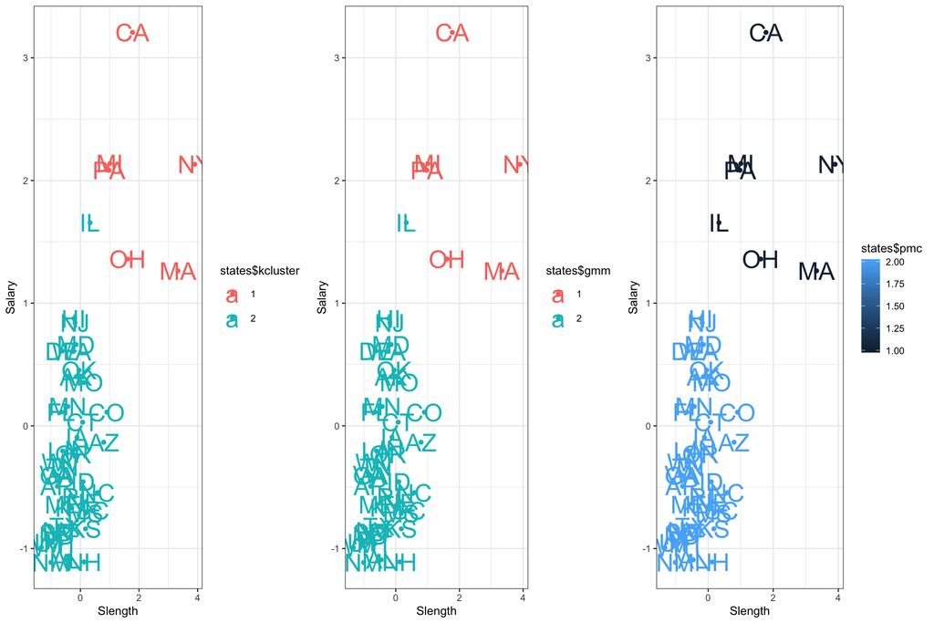

```r
suppressPackageStartupMessages(library(gridExtra))
p1<-ggplot(as.data.frame(data_scaled), aes(x=as.data.frame(data_scaled)$slength, y=as.data.frame(data_scaled)$salary, label=Pdata_sub$stateabv,color = states$kcluster)) +
  geom_point() +
  theme_bw() +
   geom_text(label=Pdata_sub$stateabv, size=8)+
  scale_fill_manual(values=c("red","blue")) +
  labs(x = "Slength",
       y = "Salary")

p2<-ggplot(as.data.frame(data_scaled), aes(x=as.data.frame(data_scaled)$slength, y=as.data.frame(data_scaled)$salary, label=Pdata_sub$stateabv,color = states$gmm)) +
  geom_point() +
  theme_bw() +
   geom_text(label=Pdata_sub$stateabv, size=8)+
  scale_fill_manual(values=c("red","blue")) +
  labs(x = "Slength",
       y = "Salary")

p3<-ggplot(as.data.frame(data_scaled), aes(x=as.data.frame(data_scaled)$slength, y=as.data.frame(data_scaled)$salary, label=Pdata_sub$stateabv,color = states$pmc)) +
  geom_point() +
  theme_bw() +
   geom_text(label=Pdata_sub$stateabv, size=8)+
  scale_fill_manual(values=c("red","blue")) +
  labs(x = "Slength",
       y = "Salary")
grid.arrange(p1, p2, p3,
             ncol = 3)
```

The three plots are similar. In fact the k-means and the GMM produce the same clustering essentially. PAM produces a slightly different cluster where an additional data point is included (which actually makes sense). The rest of the characteristics in terms of inter-cluster distances cross cluster distances, etc. match what is already expected from subsections 5, 6 and 7.

### 9. Validate

Validation of kmeans:

```r
internal <- clValid(data_scaled, 2:15,
                    clMethods = c("kmeans"),
                    validation = "internal"); summary(internal)
```

```
##
## Clustering Methods:
##  kmeans
##
## Cluster sizes:
##  2 3 4 5 6 7 8 9 10 11 12 13 14 15
##
## Validation Measures:
##                            2       3       4       5       6       7       8       9      10      11      12      13      14      15
##
## kmeans Connectivity   8.4460 10.8960 16.1885 28.7437 30.7437 37.5266 39.4552 40.8694 45.6623 45.1560 48.0115 49.5115 56.8671 66.7671
##        Dunn           0.1735  0.2581  0.2562  0.1090  0.1090  0.1108  0.1260  0.1324  0.1386  0.2518  0.2559  0.2559  0.1937  0.1434
##        Silhouette     0.6458  0.6131  0.4932  0.3042  0.2858  0.2750  0.3131  0.3307  0.3288  0.3395  0.3363  0.3250  0.2943  0.2584
##
## Optimal Scores:
##
##              Score  Method Clusters
## Connectivity 8.4460 kmeans 2
## Dunn         0.2581 kmeans 3
## Silhouette   0.6458 kmeans 2
```

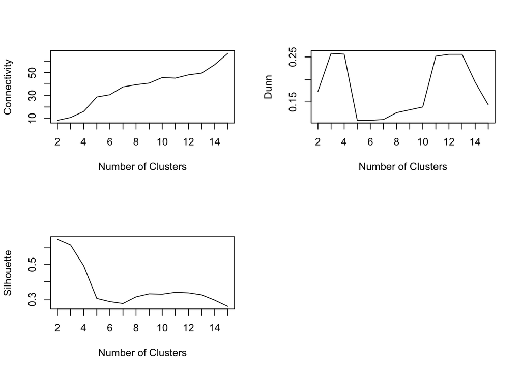

```r
par(mfrow = c(2, 2))
plot(internal, legend = FALSE,
     type = "l",
     main = " ")
```

Validation of GMM:

```r
suppressPackageStartupMessages(library(mclust))
internal <- clValid(data_scaled, 2:15,
                    clMethods = c("model"),
                    validation = "internal"); summary(internal)
```

```
##
## Clustering Methods:
##  model
##
## Cluster sizes:
##  2 3 4 5 6 7 8 9 10 11 12 13 14 15
##
## Validation Measures:
##                           2       3       4       5       6       7       8       9      10      11      12      13      14      15
##
## model Connectivity  10.7393 28.6119 39.0687 67.8401 80.4806 69.9774 72.4377 46.7254 60.0976 66.6385 77.5345 79.3679 71.6575 68.6210
##       Dunn           0.1522  0.0633  0.0225  0.0258  0.0283  0.0543  0.0710  0.1810  0.0977  0.0759  0.0759  0.0775  0.0775  0.1048
##       Silhouette     0.6314  0.2588  0.1861  0.0085 -0.0562  0.0917  0.0752  0.2831  0.1905  0.1341  0.1524  0.1507  0.2316  0.2391
##
## Optimal Scores:
##
##              Score   Method Clusters
## Connectivity 10.7393 model  2
## Dunn          0.1810 model  9
## Silhouette    0.6314 model  2
```

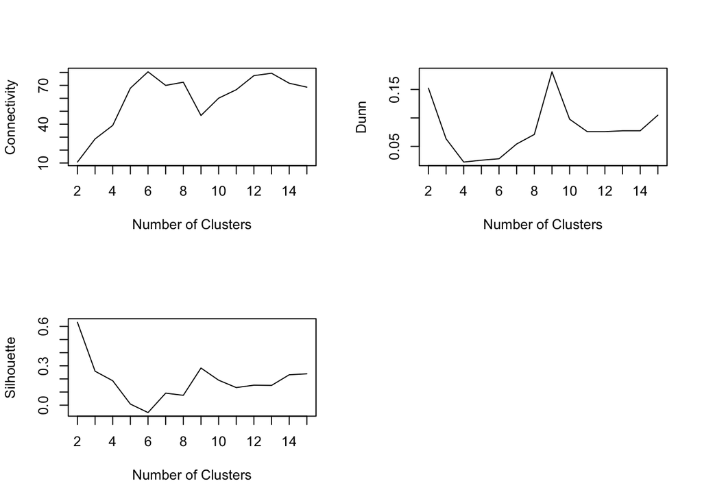

```r
par(mfrow = c(2, 2))
plot(internal, legend = FALSE,
     type = "l",
     main = " ")
```

Validation of PAM:

```r
library(mclust)
internal <- clValid(data_scaled, 2:15,
                    clMethods = c("pam"),
                    validation = "internal"); summary(internal)
```

```
##
## Clustering Methods:
##  pam
##
## Cluster sizes:
##  2 3 4 5 6 7 8 9 10 11 12 13 14 15
##
## Validation Measures:
##                         2       3       4       5       6       7       8       9      10      11      12      13      14      15
##
## pam Connectivity   7.9071 21.2952 25.4798 26.3464 35.7008 42.7266 49.2762 51.2762 53.8071 55.3302 57.6079 59.5413 64.0810 66.9194
##     Dunn           0.1673  0.0324  0.0332  0.0670  0.0731  0.0991  0.1019  0.1019  0.1130  0.1130  0.1581  0.1745  0.1745  0.2661
##     Silhouette     0.6204  0.2530  0.2673  0.2841  0.2993  0.2682  0.2564  0.2385  0.2415  0.2737  0.2697  0.2715  0.2776  0.2845
##
## Optimal Scores:
##
##              Score  Method Clusters
## Connectivity 7.9071 pam    2
## Dunn         0.2661 pam    15
## Silhouette   0.6204 pam    2
```

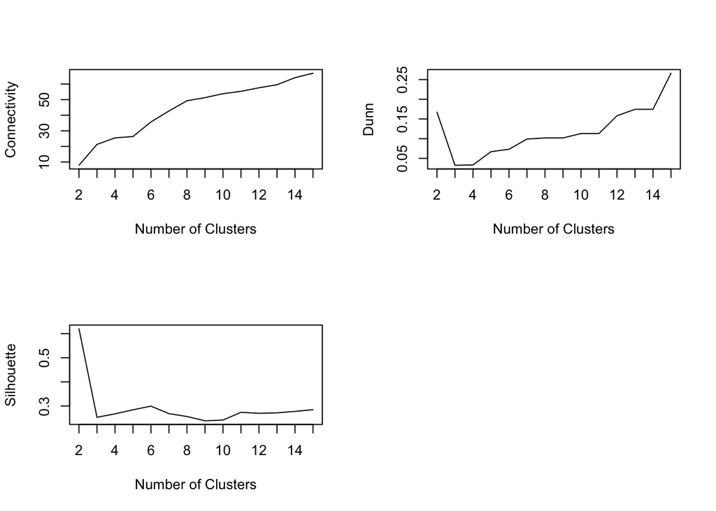

```r
par(mfrow = c(2, 2))
plot(internal, legend = FALSE,
     type = "l",
     main = " ")
```

#### a.

Even though the actuals clusters are similiar/same for all three algorithms for k=2, it seems that the actual validation measures are different when k is not equal to two. For different algorithms, the optimal value of k is different.

#### b.

It’s not clear (not from the validation measures) but from the scatterplots that PAM is the best measure at k=2. All algorithms capture the two main clusters in the data (the big cluster and the small cluster), but PAM captures that one point(IL) which is closer to the second cluster than the other two methods.

#### c.

If one was using WithinSquaresDistance(WSS) using k-means, it’s a trivial fact that as k approaches n(number of data points), WSS limits to zero.